# LAB_REPORT_Unsupervised_GuillemManeFernandez

## LAB SUBMISSION Unsupervised learning: Clustering. Detect suspicious consumptions from households.

Important Information:

- This lab report must be completed **individually**.
- Please upload your completed report to Atenea.
- You have until 9th january to submit the report.

**Objective**: The goal of this exercise is to identify households with atypical or suspicious consumption patterns compared to other users. These unusual patterns may not always indicate fraud but could be linked to system malfunctions (e.g., water leaks in toilets causing abnormally high water usage) or discrepancies such as a higher actual number of residents than recorded.

By detecting these anomalies, we aim to uncover potential issues and inefficiencies, allowing for timely interventions. The objective is to develop a clustering model to identify households exhibiting these atypical consumption behaviors. Analyze the results to determine which features contribute most to the detection of anomalies.

**Dataset Description**

The dataset is located in: **`Data/ Labsubmission_suspicious_consumption_dataset.xlsx`**

This shyntetic dataset for identifying suspicious consumption patterns in households includes the following features:

- `Household_ID`: Unique identifier for each household.
- `Daily_Electricity_kWh`: Daily electricity consumption in kWh.
- `Daily_Water_Liters`: Daily water consumption in liters.
- `Daily_Gas_CubicMeters`: Daily gas consumption in cubic meters.
- `Num_Residents`: Number of residents in the household.
- `Temperature_C`: Average daily temperature in Celsius.
- `Humidity_Percent`: Average daily humidity in percentage.

# Import libraries

```python
import pandas as pd
import matplotlib.pyplot as plt
import seaborn as sns
import warnings

# To suppress all warnings
warnings.filterwarnings("ignore")
```

# Load dataset

```python
url = 'https://raw.githubusercontent.com/sbarja/course2425_datascience4energysystems/main/Data/Labsubmission_suspicious_consumption_dataset.xlsx'
dataset = pd.read_excel(url)
```

```python
dataset.head(5)
```

|  | Household_ID | Daily_Electricity_kWh | Daily_Water_Liters | Daily_Gas_CubicMeters | Num_Residents | Temperature_C | Humidity_Percent |
| --- | --- | --- | --- | --- | --- | --- | --- |
| 0 | 1 | 34.967142 | 219.967772 | 3.649643 | 4 | 19.381337 | 29.826612 |
| 1 | 2 | 28.617357 | 196.231684 | 4.710963 | 2 | 22.289028 | 21.676741 |
| 2 | 3 | 36.476885 | 152.981518 | 3.415160 | 1 | 17.515340 | 58.139809 |
| 3 | 4 | 45.230299 | 117.653161 | 4.384077 | 2 | 19.087155 | 51.286175 |
| 4 | 5 | 27.658466 | 184.911166 | 1.212771 | 5 | 15.050211 | 47.743436 |

```python
print(dataset.dtypes)
print()
print(dataset.isna().sum())
```

```
Household_ID               int64
Daily_Electricity_kWh    float64
Daily_Water_Liters       float64
Daily_Gas_CubicMeters    float64
Num_Residents              int64
Temperature_C            float64
Humidity_Percent         float64
dtype: object

Household_ID             0
Daily_Electricity_kWh    0
Daily_Water_Liters       0
Daily_Gas_CubicMeters    0
Num_Residents            0
Temperature_C            0
Humidity_Percent         0
dtype: int64
```

# **1. Understanding the data**

It is necessary to visualize and understand the data we are going to work with, as well as to know its characteristics.

- How many households are in the dataset? How many attributes has each household?
- Is there any missing data?
- Statistical summary of the input data set (Statistics Table)

How many households that the dataset have? How many features there are?

```python
print(len(dataset))
print()
print(len(dataset.columns))
print('Actually there are 6 features considering one column is Household_ID')
```

```
1000

7
Actually there are 6 features considering one column is Household_ID
```

Is there any missing data?

```python
dataset.isna().sum()
```

```
Household_ID             0
Daily_Electricity_kWh    0
Daily_Water_Liters       0
Daily_Gas_CubicMeters    0
Num_Residents            0
Temperature_C            0
Humidity_Percent         0
dtype: int64
```

Statistical summary of the data set.

```python
dataset.describe()
```

|  | Household_ID | Daily_Electricity_kWh | Daily_Water_Liters | Daily_Gas_CubicMeters | Num_Residents | Temperature_C | Humidity_Percent |
| --- | --- | --- | --- | --- | --- | --- | --- |
| count | 1000.000000 | 1000.000000 | 1000.000000 | 1000.000000 | 1000.000000 | 1000.000000 | 1000.000000 |
| mean | 500.500000 | 37.420246 | 191.867931 | 6.199373 | 3.055000 | 19.684060 | 49.840213 |
| std | 288.819436 | 27.322164 | 143.810457 | 4.658273 | 1.398546 | 4.931097 | 9.854691 |
| min | 1.000000 | -2.412673 | 2.980568 | -1.039024 | 1.000000 | 4.961838 | 18.232962 |
| 25% | 250.750000 | 24.371303 | 123.501764 | 3.857672 | 2.000000 | 16.424893 | 43.431399 |
| 50% | 500.500000 | 31.520594 | 159.724794 | 5.315209 | 3.000000 | 19.827668 | 49.800535 |
| 75% | 750.250000 | 39.175583 | 200.650271 | 6.776582 | 4.000000 | 22.927253 | 56.523122 |
| max | 1000.000000 | 253.381810 | 1146.323523 | 34.284502 | 5.000000 | 36.215465 | 81.129102 |

Set the household_ID as the index

```python
dataset.set_index('Household_ID', inplace=True)
```

```python
dataset.head(3)
```

| Household_ID | Daily_Electricity_kWh | Daily_Water_Liters | Daily_Gas_CubicMeters | Num_Residents | Temperature_C | Humidity_Percent |
| --- | --- | --- | --- | --- | --- | --- |
| 1 | 34.967142 | 219.967772 | 3.649643 | 4 | 19.381337 | 29.826612 |
| 2 | 28.617357 | 196.231684 | 4.710963 | 2 | 22.289028 | 21.676741 |
| 3 | 36.476885 | 152.981518 | 3.415160 | 1 | 17.515340 | 58.139809 |

# **2. Visualize the data**.

A visual way to understand the input data.

- Histogram
- Density curve
- Boxplots
- Scatter plots
- Correlation matrix

Plot the histogram of each feature

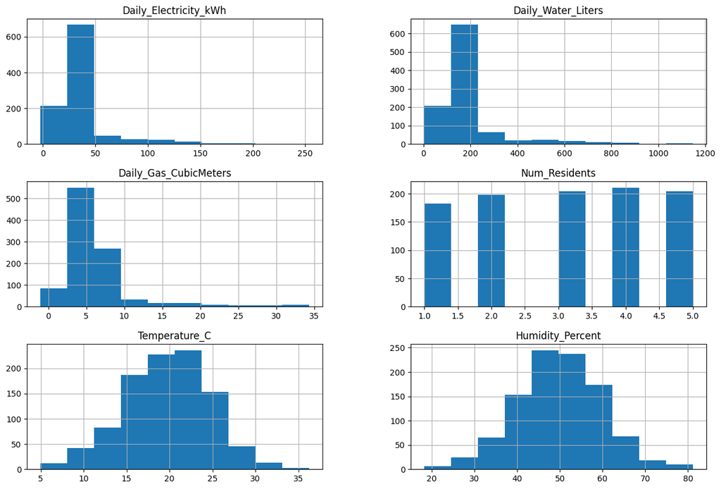

```python
#Histogram plot
dataset.hist(figsize=(15,10))
plt.show()
```

Plot the density plot of each feature

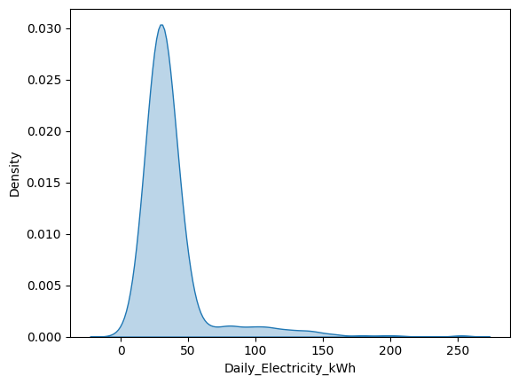

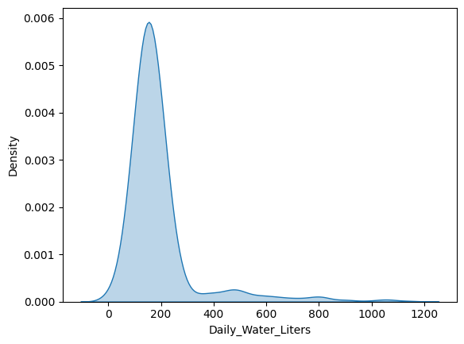

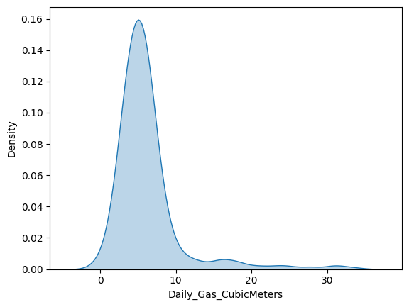

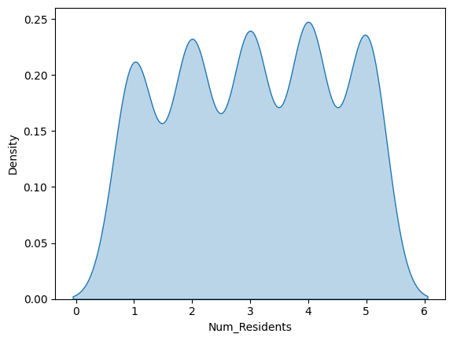

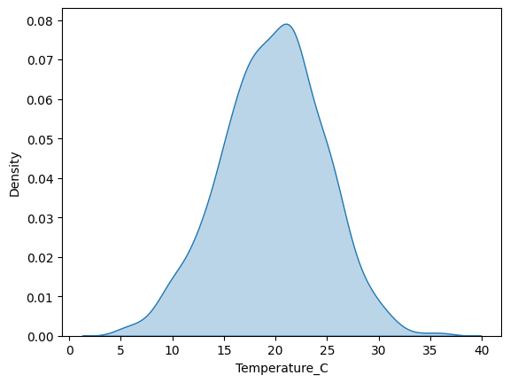

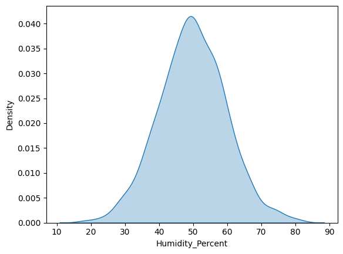

```python
#Density plot

variables = dataset.columns

for variables in variables:
  sns.kdeplot(data=dataset, x=variables, fill=True, alpha=0.3, label='Overall Distribution')
  plt.show()
```

Boxplot of each feature. Should we delete the outliers?

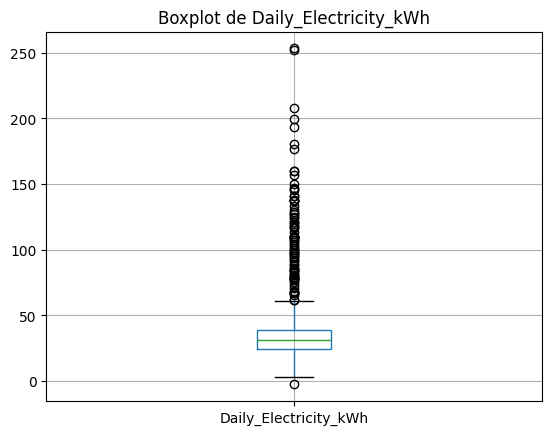

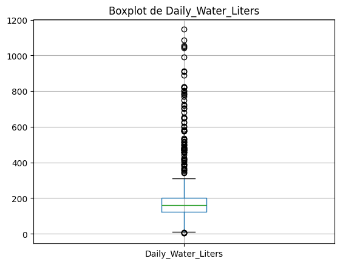

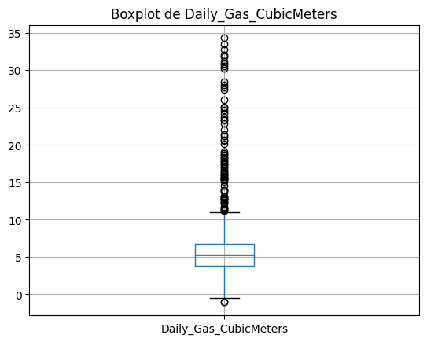

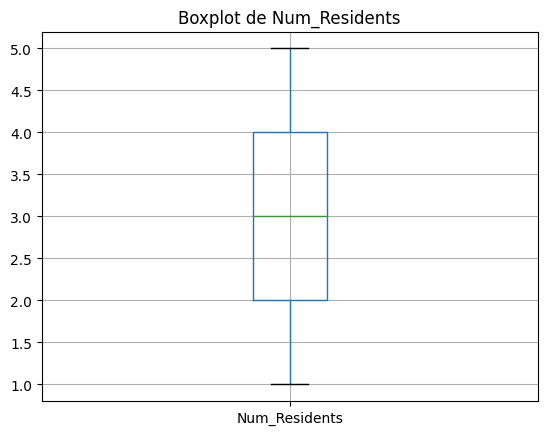

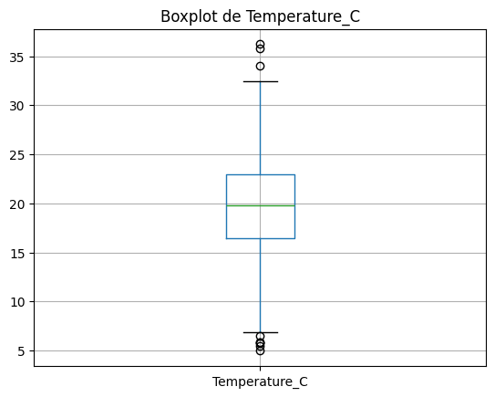

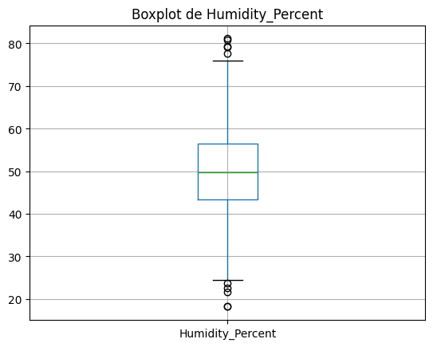

```python
#Boxplots

variables = dataset.columns

for var in variables:
    dataset.boxplot(column=var)
    plt.title(f'Boxplot de {var}')
    plt.show()
```

Multivariate plot: Scatter plot

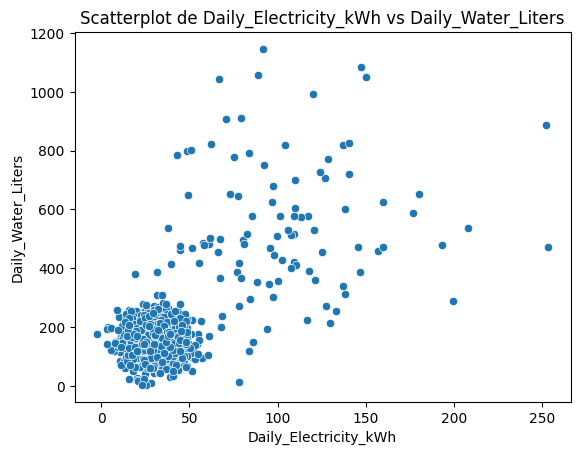

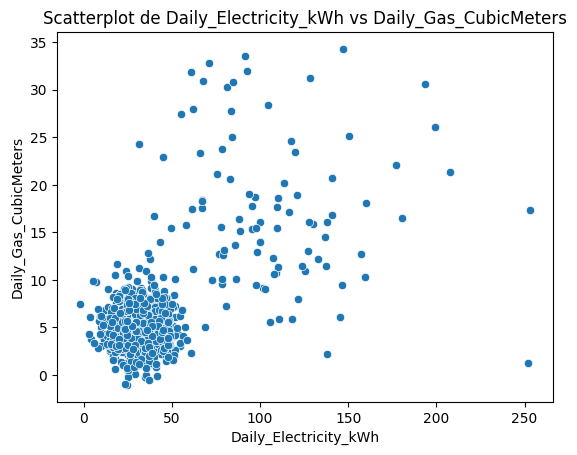

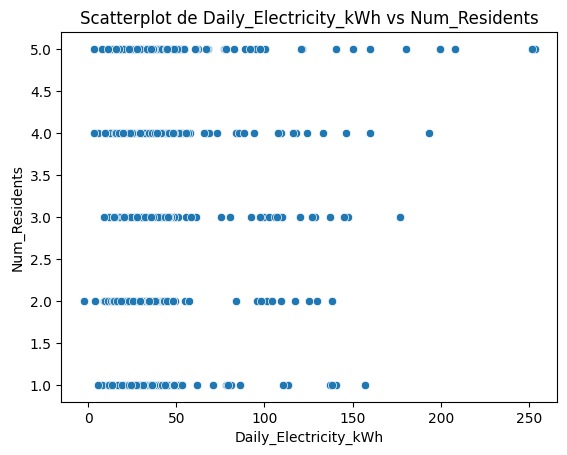

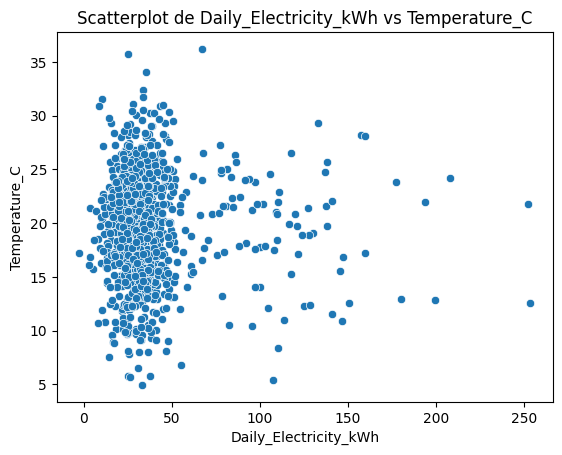

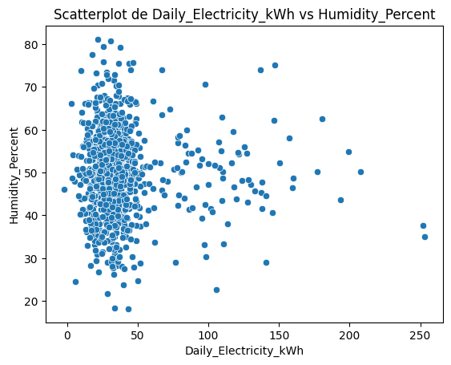

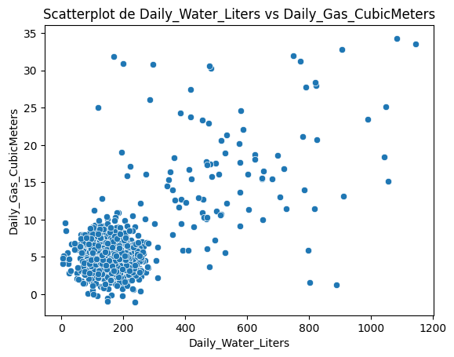

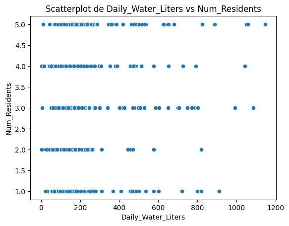

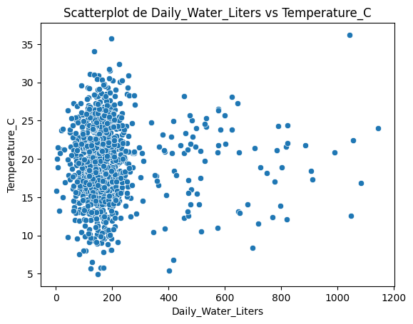

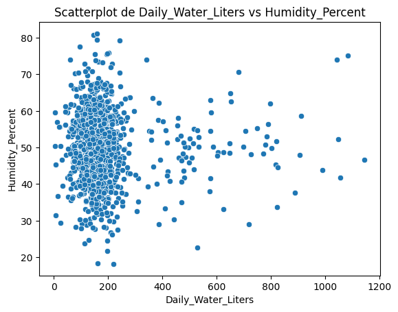

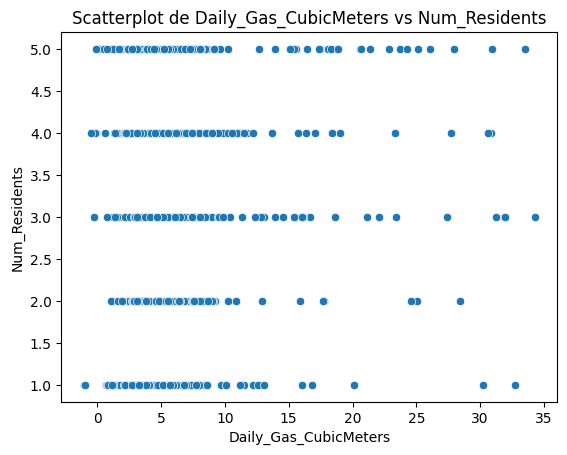

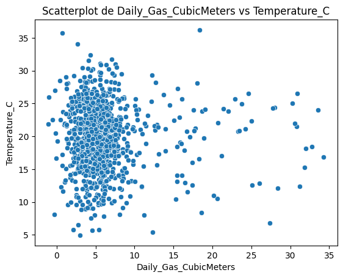

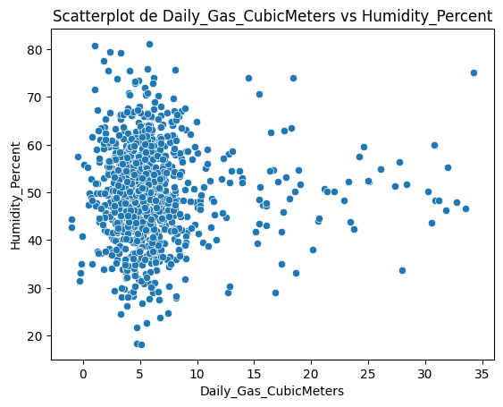

[3 more figures not shown]

```python
variables = dataset.columns

for i, var1 in enumerate(variables):
    for var2 in variables[i+1:]:
        sns.scatterplot(data=dataset, x=var1, y=var2)
        plt.title(f'Scatterplot de {var1} vs {var2}')
        plt.show()
```

Multivariate plot: Correlation matrix.

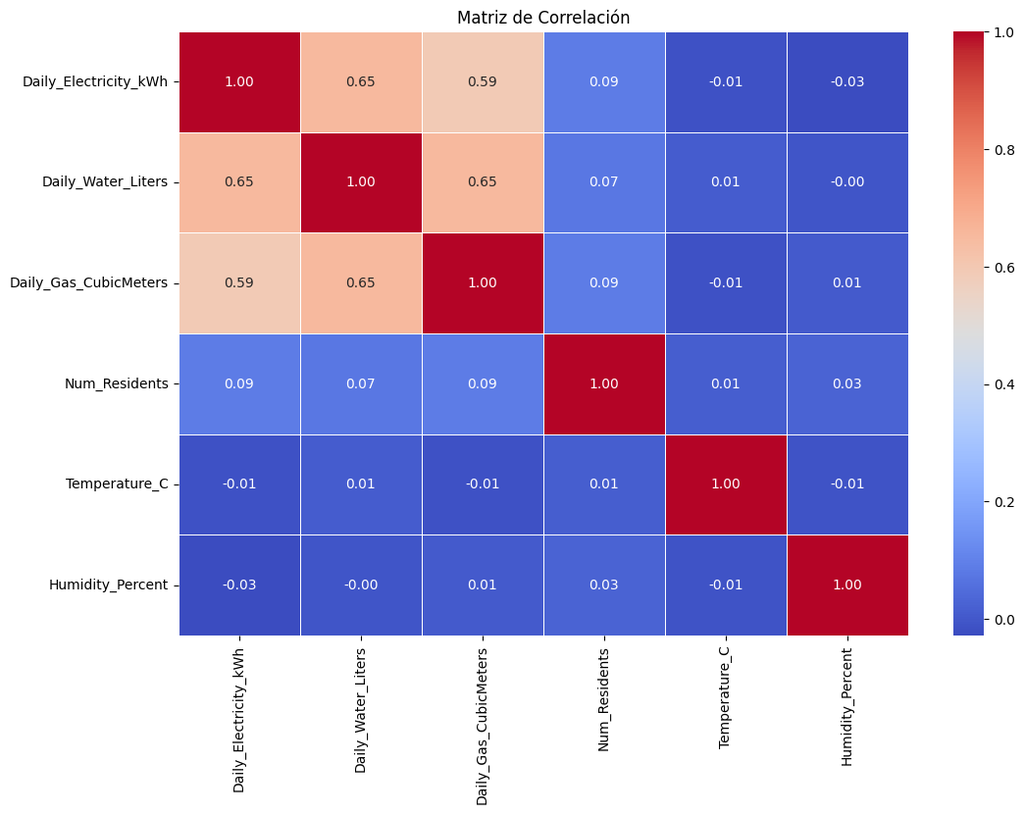

```python
# calculate the correlation matrix
corr_matrix = dataset.corr()

plt.figure(figsize=(12, 8))
sns.heatmap(corr_matrix, annot=True, cmap='coolwarm', fmt='.2f', linewidths=0.5)

plt.title('Matriz de Correlación')
plt.show()
```

# 3. **Prepare the data.**

- Take care of missing data (if necessary)
- Scale the data

Take care of missing data (if necessary)

```python
dataset.isna().sum()
```

```
Daily_Electricity_kWh    0
Daily_Water_Liters       0
Daily_Gas_CubicMeters    0
Num_Residents            0
Temperature_C            0
Humidity_Percent         0
dtype: int64
```

```python
dataset.dropna(inplace=True)
```

Scale the data using StandardScaler()

```python
from sklearn.cluster import AgglomerativeClustering
from sklearn.preprocessing import StandardScaler

scaler = StandardScaler()
dataset_scaled = scaler.fit_transform(dataset)
```

Dimensionality reduction with PCA: Reduce the scaled dataset to 2 principal components and plot them on a 2D graph.

```python
# PCA for dimensionality reduction
from sklearn.decomposition import PCA

pca = PCA(n_components=2)
results_pca = pca.fit_transform(dataset_scaled)
print(results_pca)
```

```
[[-0.15448712  1.19625805]
 [-0.40846319  2.6529965 ]
 [-0.68526015  0.24141834]
 ...
 [ 3.0631933  -0.12151972]
 [-0.72676747 -0.87949027]
 [-0.53012821  0.88047627]]
```

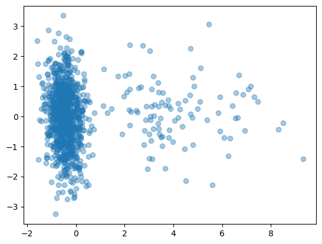

```python
# Visualize the principal components in a plot
plt.scatter(results_pca[:, 0], results_pca[:, 1],alpha=0.4)
plt.show()
```

# 4. Unsupervised Learning Model Building: Houses Clustering using K-means

Find the optimal number of clusters using the Elbow method

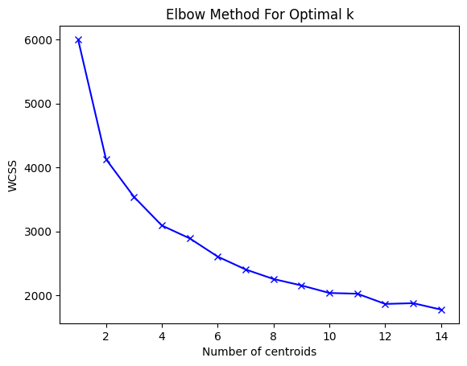

```python
# Elbow method
import matplotlib.pyplot as plt
from sklearn.cluster import KMeans

dataset_scaled_4 = dataset_scaled.copy()

wcss = []
K = range(1,15)

for k in K:
    km = KMeans(n_clusters=k)
    km = km.fit(dataset_scaled_4)
    wcss.append(km.inertia_)
plt.plot(K, wcss, 'bx-')
plt.xlabel('Number of centroids')
plt.ylabel('WCSS')
plt.title('Elbow Method For Optimal k')
plt.show()
```

Use K-means to find the cluster for each household

```python
# Train the K-means for the optimal number of clusters given the result of the Elbow method.
kmeans = KMeans(n_clusters=2, random_state=0).fit(dataset_scaled_4)
y_kmeans = kmeans.predict(dataset_scaled_4)
```

Print the clusters labels

```python
print(y_kmeans)
```

[output not shown]

Visualize the K-Means Clustering results obtained before on the PCA Components plot.

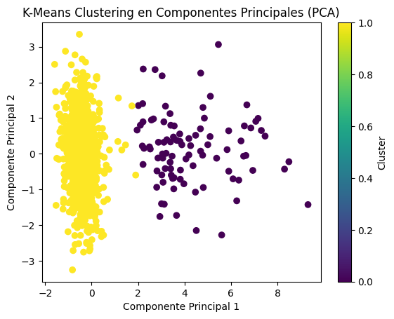

```python
# Visualize K-Means Clustering on PCA Components (each data point should be color according to the cluster labels)

# Crear el scatter plot
plt.scatter(results_pca[:, 0], results_pca[:, 1], c=y_kmeans, cmap='viridis')
plt.xlabel('Componente Principal 1')
plt.ylabel('Componente Principal 2')
plt.title('K-Means Clustering en Componentes Principales (PCA)')
plt.colorbar(label='Cluster')
plt.show()
```

Add cluster labels back to the original dataset (create a new column named "cluster" in the original dataset)

```python
# Add cluster labels to the original dataset (create a new column)
dataset['cluster'] = y_kmeans
dataset.head(3)
```

| Household_ID | Daily_Electricity_kWh | Daily_Water_Liters | Daily_Gas_CubicMeters | Num_Residents | Temperature_C | Humidity_Percent | cluster |
| --- | --- | --- | --- | --- | --- | --- | --- |
| 1 | 34.967142 | 219.967772 | 3.649643 | 4 | 19.381337 | 29.826612 | 1 |
| 2 | 28.617357 | 196.231684 | 4.710963 | 2 | 22.289028 | 21.676741 | 1 |
| 3 | 36.476885 | 152.981518 | 3.415160 | 1 | 17.515340 | 58.139809 | 1 |

Group the data by cluster label (.groupby('cluster')) and compute the mean values (.mean()). and store that into a DataFrame that displays the mean values of each feature for clusters labeled as 0 and 1.

```python
dataset_grupmean = dataset.copy()
dataset_grupmean = dataset_grupmean.groupby('cluster').mean()
```

```python
dataset_grupmean.head(3)
```

| cluster | Daily_Electricity_kWh | Daily_Water_Liters | Daily_Gas_CubicMeters | Num_Residents | Temperature_C | Humidity_Percent |
| --- | --- | --- | --- | --- | --- | --- |
| 0 | 105.794123 | 553.348417 | 17.219082 | 3.387097 | 19.492230 | 49.559277 |
| 1 | 30.409474 | 154.803228 | 5.069458 | 3.020948 | 19.703729 | 49.869019 |

Create a plot to visualize the average feature values for clusters 0 and 1 using bar plots and identify which features are most meaningful for detecting suspicious consumption.

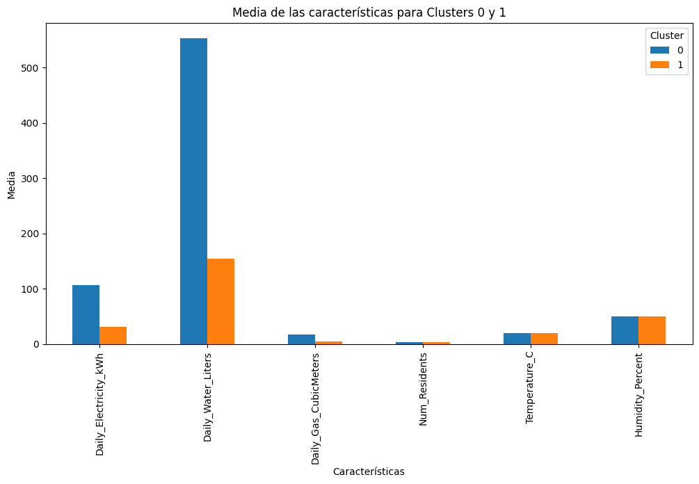

```python
# Identify potential anomalous households based on extreme feature averages

clusters_01 = dataset_grupmean.loc[[0, 1]]

clusters_01.T.plot(kind='bar', figsize=(12, 6))
plt.title('Media de las características para Clusters 0 y 1')
plt.xlabel('Características')
plt.ylabel('Media')
plt.legend(title='Cluster')
plt.show()
```

# Final conclusion

Summarize the outcomes of the code developed, including a brief overview of the clustering process and the results obtained. Highlight any key findings or patterns observed after clustering the households, such as distinctive characteristics that might lead to suspicious consumption

## Conclusions:

This report addresses a problem of identifying suspicious or atypical consumption patterns in households using unsupervised learning techniques.

First, the quality of the dataset was analysed as well as the study of individual variables. Then, clustering techniques such as PCA, K-means and the elbow method were used to determine the ideal number of clusters. Finally, the cluster results were plotted in order to extract conclusions in a more convenient way.

It can be seen that the means of number of residents, temperature and humidity are not too different between clusters. On the other hand, there is a large difference in the consumption of water, electricity and gas. This could indicate a malfunctioning of some device, of some sector of the system or even some user doing fraud.

I think it would be interesting to study the cases where this difference between cluster 0 and cluster 1 of the consumption for the three most relevant features is higher in order to study case by case. I also think it would be interesting to have more granularity of the data to be able to know if these atypical consumptions are made at atypical times or however it is continuously, this would help to know if it is a malfunction or leakage, a fraud or misuse of the facilities or a particular consumption pattern of certain users.